# Penguin Data Visualization

Tom Contreras

2023-10-04

# Introduction

In this document, I will explore the Palmer Penguins dataset using various data visualization techniques in R. I will use the `ggplot2` package to create plots and examine the relationship between flipper length and body mass among penguins, while considering different aspects of the data such as species and sex.

For more details on using R Markdown, [click here](http://rmarkdown.rstudio.com).

# Loading the Data

```r
library(tidyverse)
library(palmerpenguins)
```

# Load the penguins dataset

```r
data(penguins)
```

# Display a glimpse of the dataset

```r
glimpse(penguins)
```

```
## Rows: 344
## Columns: 8
## $ species           <fct> Adelie, Adelie, Adelie, Adelie, Adelie, Adelie, Adel…
## $ island            <fct> Torgersen, Torgersen, Torgersen, Torgersen, Torgerse…
## $ bill_length_mm    <dbl> 39.1, 39.5, 40.3, NA, 36.7, 39.3, 38.9, 39.2, 34.1, …
## $ bill_depth_mm     <dbl> 18.7, 17.4, 18.0, NA, 19.3, 20.6, 17.8, 19.6, 18.1, …
## $ flipper_length_mm <int> 181, 186, 195, NA, 193, 190, 181, 195, 193, 190, 186…
## $ body_mass_g       <int> 3750, 3800, 3250, NA, 3450, 3650, 3625, 4675, 3475, …
## $ sex               <fct> male, female, female, NA, female, male, female, male…
## $ year              <int> 2007, 2007, 2007, 2007, 2007, 2007, 2007, 2007, 2007…
```

# Scatter Plots

#### Scatter Plot: Flipper Length vs. Body Mass

We can create a basic scatter plot to visualize the relationship between flipper length and body mass among penguins:

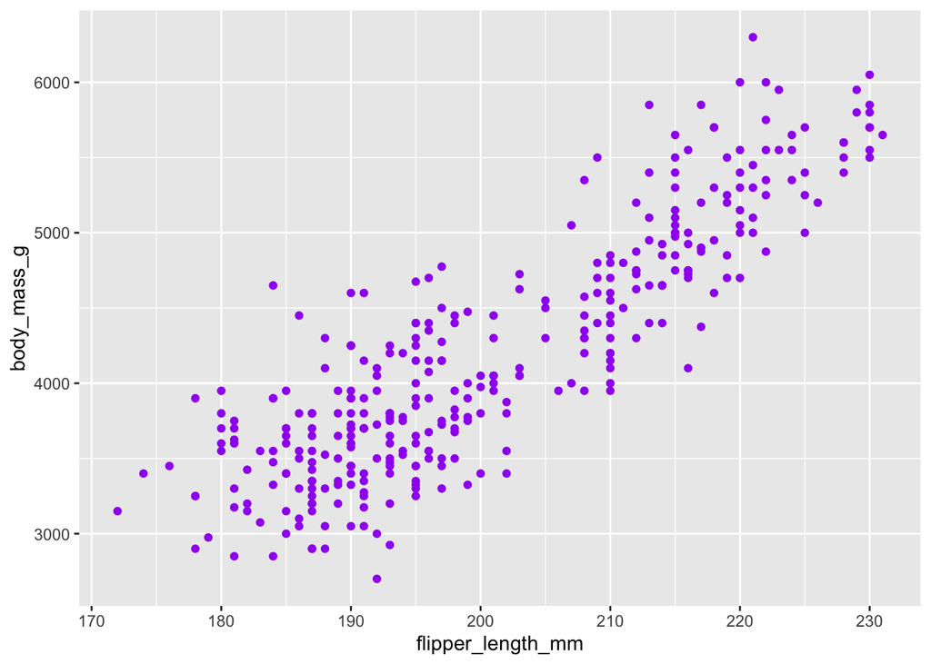

```r
# Scatter plot of flipper length vs. body mass
ggplot(data = penguins, aes(x = flipper_length_mm, y = body_mass_g)) +
  geom_point(color = "purple")
```

#### Scatter Plot with Species Differentiation

Now, let’s add color differentiation for different penguin species:

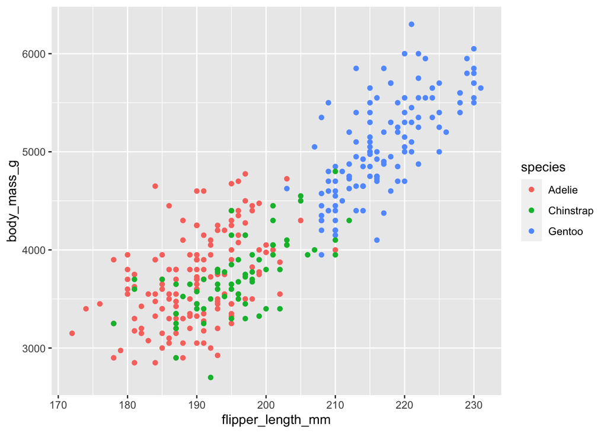

```r
# Scatter plot with color-coded points for species
ggplot(data = penguins, aes(x = flipper_length_mm, y = body_mass_g)) +
  geom_point(aes(color = species))
```

#### Scatter Plot with Species and Shape Differentiation

To further enhance the plot, we can use both color and shape to differentiate the points by species:

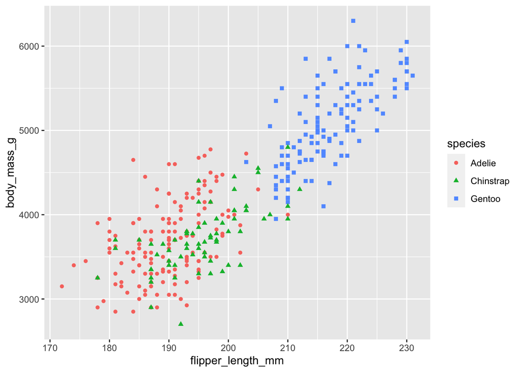

```r
# Scatter plot with color-coded and shape-coded points for species
ggplot(data = penguins, aes(x = flipper_length_mm, y = body_mass_g)) +
  geom_point(aes(color = species, shape = species))
```

#### Faceted Scatter Plots by Sex

Now, let’s create faceted scatter plots by sex, considering the flipper length and body mass:

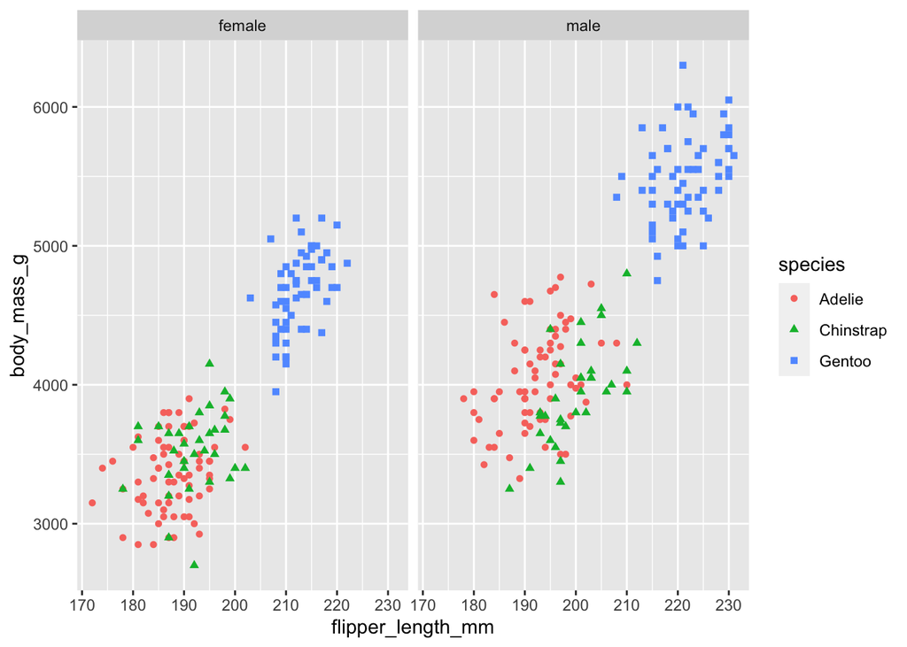

```r
# Faceted scatter plots by sex with color-coded and shape-coded points for species
penguins %>%
  drop_na(sex) %>%
  ggplot(aes(x=flipper_length_mm,y=body_mass_g))+
  geom_point(aes(color=species,
                 shape=species)) +
  facet_wrap(~sex)
```

# Conclusion

In this comprehensive analysis of the Palmer Penguins dataset, I employed a range of data visualization techniques, primarily utilizing the ggplot2 package, to delve into the intricate relationship between flipper length and body mass among penguins. Through my exploration, I unearthed valuable insights:

```
Species Variation: The visualizations highlighted distinct patterns in flipper length and body mass for different penguin species.

Sexual Dimorphism: Faceted scatter plots by sex revealed intriguing gender-based variations in penguin biology. Male and female penguins within the same species exhibited divergent size distributions, shedding light on potential sexual dimorphism in these species.

Ecological Implications: The observed relationships between flipper length and body mass may have ecological significance. These attributes could be indicative of adaptation and specialization within the species, influencing their survival strategies and roles within the ecosystem.
```

In summary, the data visualizations went beyond mere observation, providing a deeper understanding of the Palmer Penguins dataset. The identified patterns hint at the intricate interplay of factors affecting these remarkable creatures in their natural habitats. This analysis serves as a foundation for further ecological investigations and underscores the power of data visualization in unraveling the secrets of the natural world.